# Meta-análisis: Suplementación en hipertrofia

Rubén Gil

2025-07-6

# 1. SetUp

Cargado de las librerías y de todos los datasets.

```r
# Cargar librerías
library(meta)
library(metafor)
library(dmetar)

# Cargar datos

  # Set de datos limpios ~ Variables categóricas
analisisglobal <- read.csv("data/datos_limpios.csv", sep = ";")

  # Es 'analisisgloblal' eliminando los outliers
analisis_outliers <- read.csv("data/datos_outliers.csv", sep = ";")

  # Es 'analisis_outliers' pero con las variables numéricas
analisis_metarregresion <- read.csv("data/datos_metarregresion.csv", sep = ";")

  # Es 'analisis_outliers' pero los suplementos han sido agrupados por categorías
analisis_supp <- read.csv("data/datos_outliers_grp.csv", sep = ";")
```

# 2. Análisis del Efecto Global

Evaluación del impacto general de la suplementación sobre la masa libre de grasa (LMB).

- Se utiliza el modelo de efectos aleatorios porque estimamos que hay un efecto diferente para cada estudio como fuente de variación adicional.

```r
# Cálculo del Meta-análisis de Diferencia de Medias (MD)
MD <- metacont(
  n.e = N_Sup,
  mean.e = LMB_Suplemento,
  sd.e = SD_Suplemento,
  n.c = N_Con,
  mean.c = LMB_Control,
  sd.c = SD_Control,
  data = analisisglobal,
  studlab = paste(Autor, Year),
  common = FALSE,
  random = TRUE,
  method.tau = "REML"
)
```

## 2.1. Forest Plot

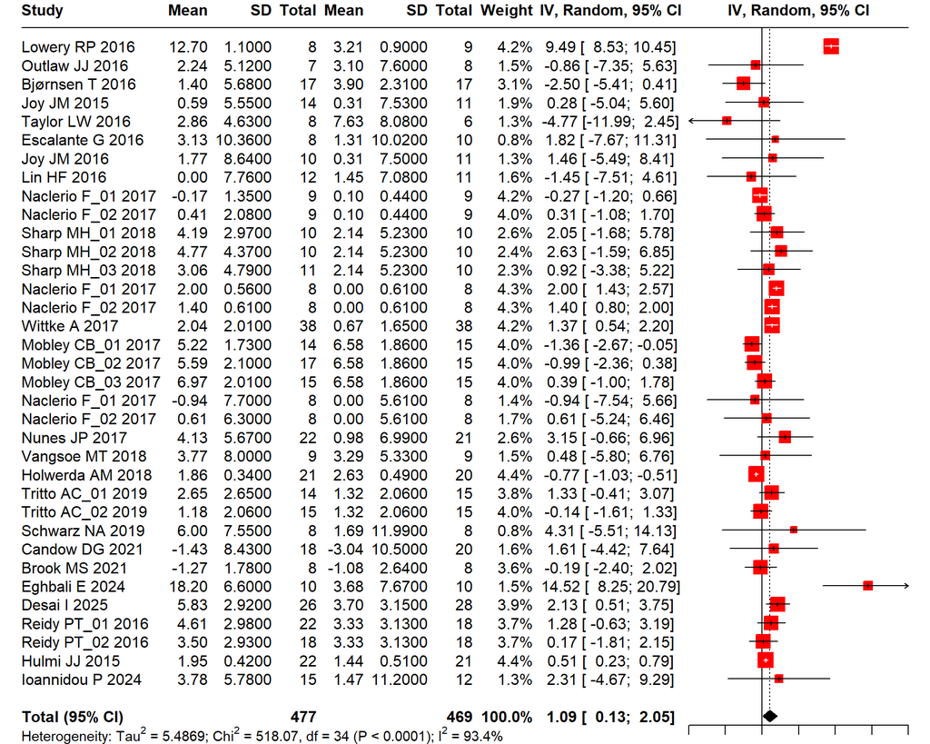

```r
forest(MD,
       comb.fixed = FALSE,
       print.pval.Q = TRUE,
       print.Q = TRUE,
       layout = "RevMan5",
       common = FALSE,
       random = TRUE,
       print.tau2 = TRUE,
       test.overall.random = TRUE,
       col.diamond = "black",
       col.square = "red",
       label.test.overall.random = TRUE,
       label.right = "Favorece suplemento",
       label.left = "Favorece control",
       col.square.lines = "red",
       spacing = 1,
       xlim = c(-10, 20))
```

## 2.2. Interpretación del output

- **MD(95% CI)**: Muestra la diferencia entre las medias de ambos grupos en porcentaje, para un intervalo de confianza (CI) del 95%.
- **I^2**: Mide la heterogeneidad entre los estudios. “Un I2 inferior al 40% sugiere una heterogeneidad baja o moderada, lo que da mayor robustez a la estimación del efecto global”. Si es mayor, simplemente indica que los estudios son muy diferentes entre sí, no que el análisis sea erróneo.

# 3. Detección de outliers

Un outlier es un resultado que está fuera del CI de la *mean difference*. Eliminarlos nos permite observar si el efecto observado es una tendencia general o depende excesivamente de resultados extremos.

```r
find.outliers(MD)
```

```
## Identified outliers (random-effects model)
## ------------------------------------------
## "Lowery RP 2016", "Mobley CB_01 2017", "Holwerda AM 2018", "Eghbali E 2024"
##
## Results with outliers removed
## -----------------------------
## Number of studies: k = 31
## Number of observations: o = 839 (o.e = 424, o.c = 415)
##
##                          MD           95%-CI    z p-value
## Random effects model 0.7173 [0.2457; 1.1889] 2.98  0.0029
##
## Quantifying heterogeneity (with 95%-CIs):
##  tau^2 = 0.5314 [0.0314; 1.0466]; tau = 0.7290 [0.1773; 1.0230]
##  I^2 = 47.1% [19.5%; 65.3%]; H = 1.38 [1.11; 1.70]
##
## Test of heterogeneity:
##      Q d.f. p-value
##  56.72   30  0.0023
##
## Details of meta-analysis methods:
## - Inverse variance method
## - Restricted maximum-likelihood estimator for tau^2
## - Q-Profile method for confidence interval of tau^2 and tau
## - Calculation of I^2 based on Q
```

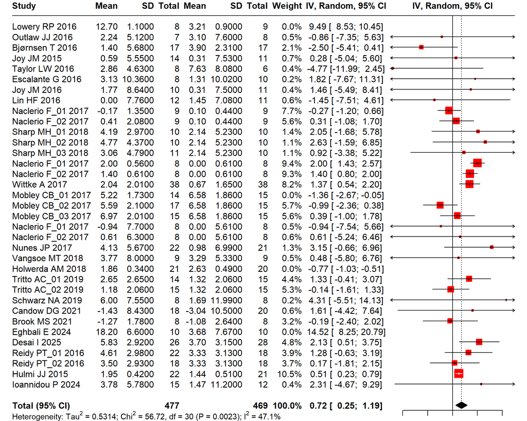

```r
# Forest plot de outliers
forest(find.outliers(MD),
       common = FALSE,
       print.pval.Q = TRUE,
       print.Q = TRUE,
       layout = "RevMan5",
       random = TRUE,
       print.tau2 = FALSE,
       test.overall.random = TRUE,
       col.diamond = "black",
       col.square = "red",
       label.test.overall.random = TRUE,
       label.right = "Favorece suplemento",
       label.left = "Favorece control",
       col.square.lines = "red",
       spacing = 1,
       xlim = c(-5, 5))
```

# 4. Nuevo análisis, sin outliers

Una vez hemos eliminado los outliers, repetimos el análisis para ver los resultados ‘reales’. La interpretación es la misma que para el anterior análisis.

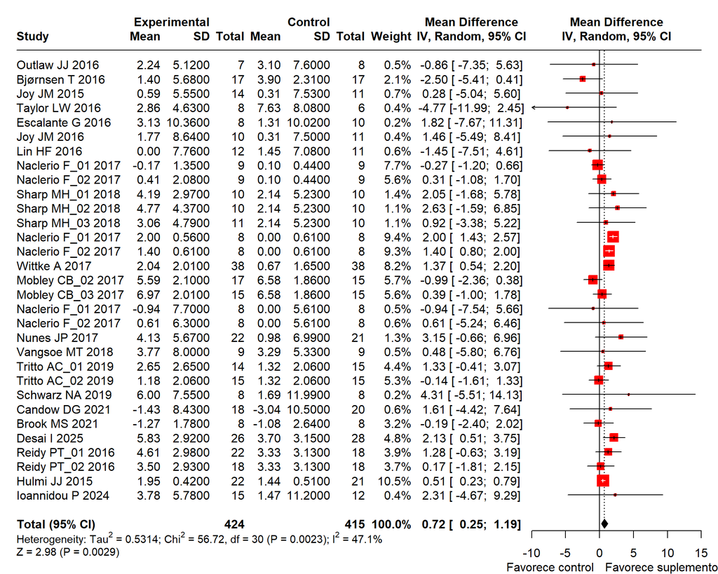

```r
MD_SO <- metacont(
  n.e = N_Sup,
  mean.e = LMB_Suplemento,
  sd.e = SD_Suplemento,
  n.c = N_Con,
  mean.c = LMB_Control,
  sd.c = SD_Control,
  data = analisis_outliers,
  studlab = paste(Autor, Year),
  common = FALSE,
  random = TRUE,
  method.tau = "REML"
)

forest(MD_SO,
       comb.fixed = FALSE,
       print.pval.Q = TRUE,
       print.Q = TRUE,
       layout = "RevMan5",
       common = FALSE,
       random = TRUE,
       print.tau2 = TRUE,
       test.overall.random = TRUE,
       col.diamond = "black",
       col.square = "red",
       label.test.overall.random = TRUE,
       label.right = "Favorece suplemento",
       label.left = "Favorece control",
       col.square.lines = "red",
       spacing = 1,
       xlim = c(-10, 15))
```

## 4.1. Comparación de modelos

Una vez hemos hecho el análisis, con y sin outliers, podemos evaluar diferencias y ver si ha sido una decisión acertada:

- **MD(95% CI)**: Aunque sigue estando desplazada hacia la suplementación, su efecto ahora es menor.
- **I^2**: Ha disminuido a la mitad, por lo que podemos decir que esos artículos contribuían desproporcionadamente a la heterogeneidad, y la decisión de eliminarlos es correcta.

# 5. Evaluación del sesgo de publicación

Queremos comprobar la ausencia de este sesgo en nuestros estudios. Este sesgo implica que hay más artículos ‘a favor’ de la suplementación, porque estudios con resultados neutros o negativos no se publican. Para ello tenemos 2 opciones:

1. **Funnel plot**: Se busca que no haya asimetría para afirmar la ausencia de este sesgo.
2. **Egger’s test**: Es la forma matemática de confirmarlo. Si p > 0.05, descartamos el sesgo

```r
# Funnel plot
funnel(MD,bg = "white",col.random = "blue",cex = 2,studlab = TRUE)
funnel(MD_SO,bg = "white",col.random = "blue",cex = 2,studlab = TRUE)

# Test de Egger
eggers.test (x=MD)
```

```
## Eggers' test of the intercept
## =============================
##
##  intercept       95% CI     t         p
##      1.012 -0.63 - 2.65 1.211 0.2343319
##
## Eggers' test does not indicate the presence of funnel plot asymmetry.
```

```r
eggers.test (x=MD_SO)
```

```
## Eggers' test of the intercept
## =============================
##
##  intercept       95% CI      t         p
##     -0.082 -0.72 - 0.56 -0.252 0.8027592
##
## Eggers' test does not indicate the presence of funnel plot asymmetry.
```

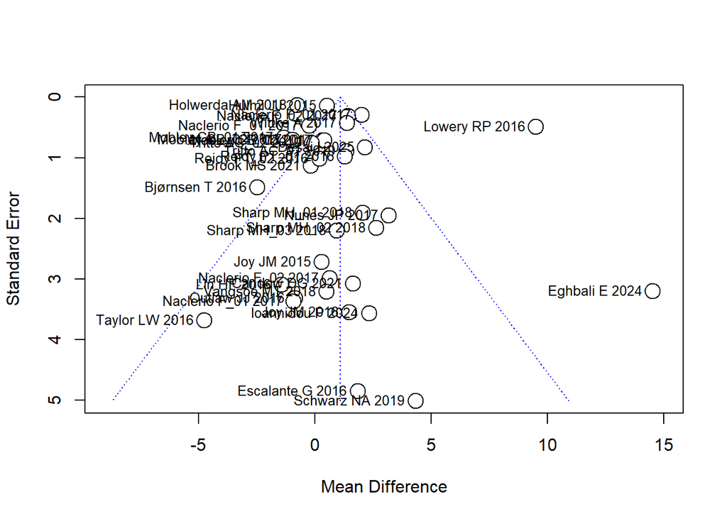

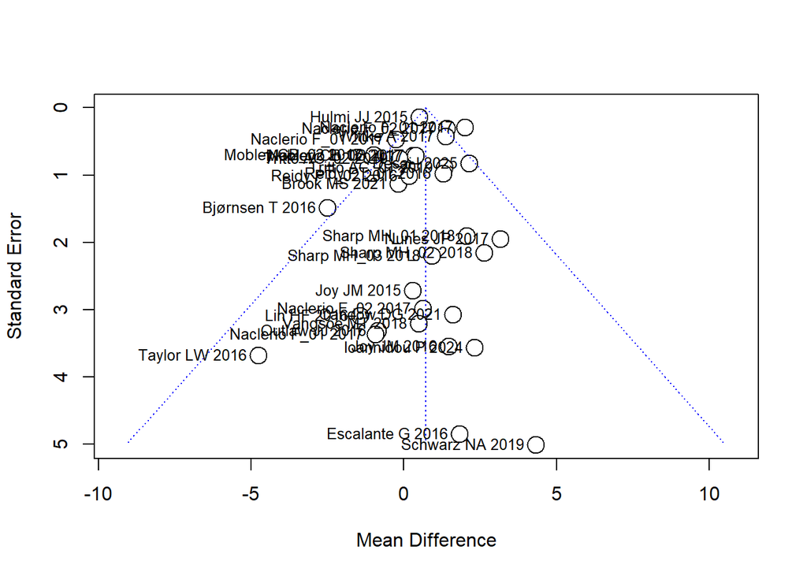

# 6. Evaluación por subgrupos

La idea es evaluar si alguna de las variables analizadas ayuda a explicar la heterogeneidad (si son o no moderadores del efecto). Las variables analizadas son:

- Duración del estudio, edad, sexo, timing de la suplementación, tipo de suplemento y estado de entrenamiento de los participantes.

El estudio de las variables devuelve los siguientes factores:

- **MD(95% CI)**: Es la diferencia de medias entre el control y ese grupo concreto.
- **p_value**: Acompaña a la MD e indica si esta es estadísticamente significativa (p<0.05).
- **Chi^2**: Indica si hay diferencias entre los grupos. Si su p_valor < 0.05, los grupos son diferentes estadísticamente hablando.
- **Forest Plot**: El forest plot se interpreta de la misma manera, pero los estudios están agrupados por categoría y cada una de ellas tiene su media como subtotal (también en negro).

## 6.1. Análisis por sexo

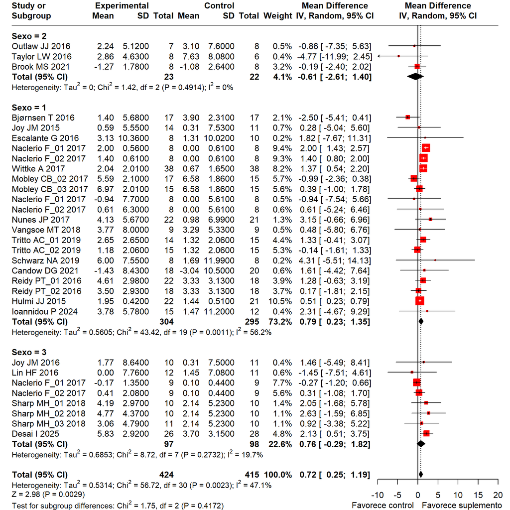

```r
g_sex <- metacont(
  n.e = N_Sup,
  mean.e = LMB_Suplemento,
  sd.e = SD_Suplemento,
  n.c = N_Con,
  mean.c = LMB_Control,
  sd.c = SD_Control,
  data = analisis_outliers,
  studlab = paste(Autor, Year),
  subgroup = Sexo,
  common = FALSE,
  random = TRUE,
  method.tau = "REML"
)

forest(g_sex,
       comb.fixed = FALSE,
       print.pval.Q = TRUE,
       print.Q = TRUE,
       layout = "RevMan5",
       common = FALSE,
       random = TRUE,
       print.tau2 = TRUE,
       test.overall.random = TRUE,
       col.diamond = "black",
       col.square = "red",
       label.test.overall.random = TRUE,
       label.right = "Favorece suplemento",
       label.left = "Favorece control",
       col.square.lines = "red",
       spacing = 1,
       xlim = c(-10, 20))
```

## 6.2. Análisis por suplemento

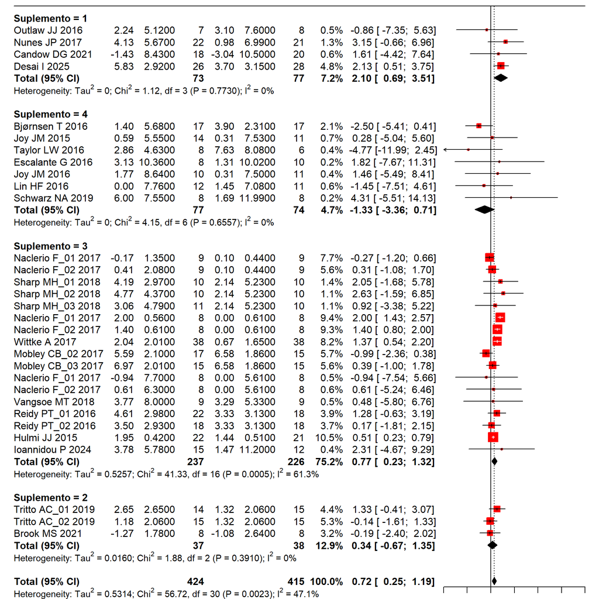

```r
g_sup <- metacont(
  n.e = N_Sup,
  mean.e = LMB_Suplemento,
  sd.e = SD_Suplemento,
  n.c = N_Con,
  mean.c = LMB_Control,
  sd.c = SD_Control,
  data = analisis_supp,
  studlab = paste(Autor, Year),
  subgroup = Suplemento,
  common = FALSE,
  random = TRUE,
  method.tau = "REML"
)

forest(g_sup,
       comb.fixed = FALSE,
       print.pval.Q = TRUE,
       print.Q = TRUE,
       layout = "RevMan5",
       common = FALSE,
       random = TRUE,
       print.tau2 = TRUE,
       test.overall.random = TRUE,
       col.diamond = "black",
       col.square = "red",
       label.test.overall.random = TRUE,
       label.right = "Favorece suplemento",
       label.left = "Favorece control",
       col.square.lines = "red",
       spacing = 1,
       xlim = c(-10, 20))
```

## 6.3. Análisis por duración del estudio

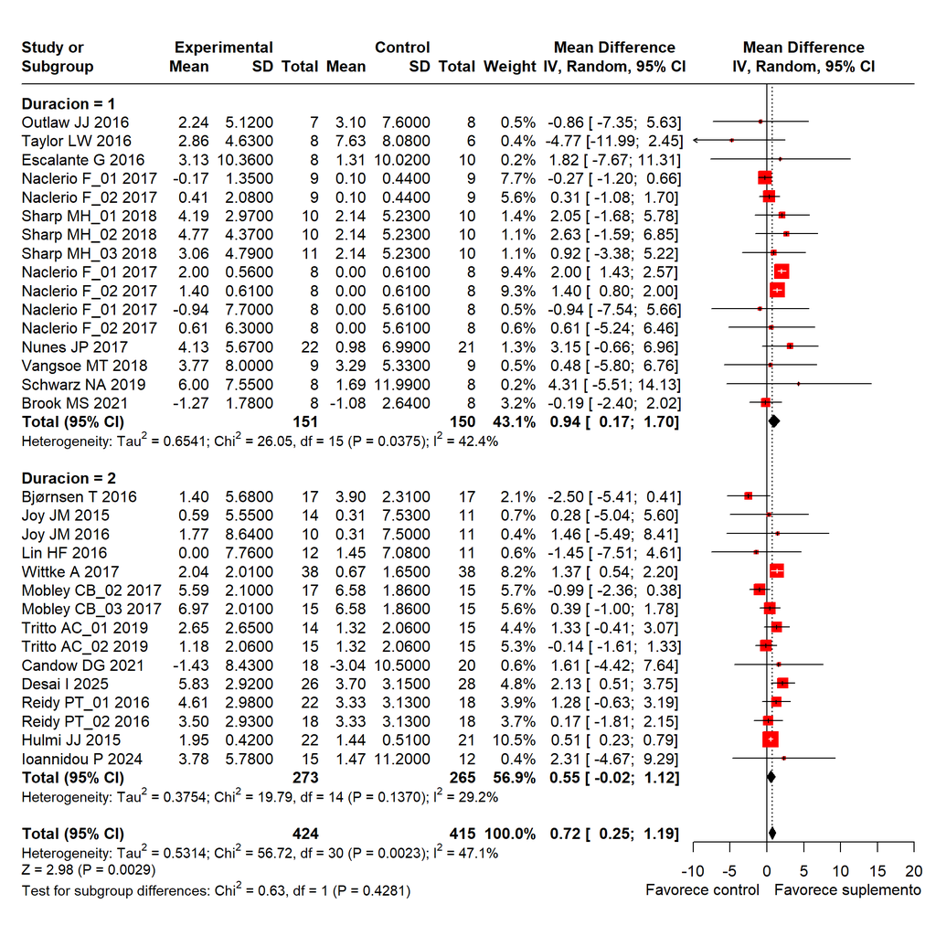

```r
g_duracion <- metacont(
  n.e = N_Sup,
  mean.e = LMB_Suplemento,
  sd.e = SD_Suplemento,
  n.c = N_Con,
  mean.c = LMB_Control,
  sd.c = SD_Control,
  data = analisis_outliers,
  studlab = paste(Autor, Year),
  subgroup = Duracion,
  common = FALSE,
  random = TRUE,
  method.tau = "REML"
)

forest(g_duracion,
       comb.fixed = FALSE,
       print.pval.Q = TRUE,
       print.Q = TRUE,
       layout = "RevMan5",
       common = FALSE,
       random = TRUE,
       print.tau2 = TRUE,
       test.overall.random = TRUE,
       col.diamond = "black",
       col.square = "red",
       label.test.overall.random = TRUE,
       label.right = "Favorece suplemento",
       label.left = "Favorece control",
       col.square.lines = "red",
       spacing = 1,
       xlim = c(-10, 20))
```

## 6.4. Análisis por el timing de la suplementación

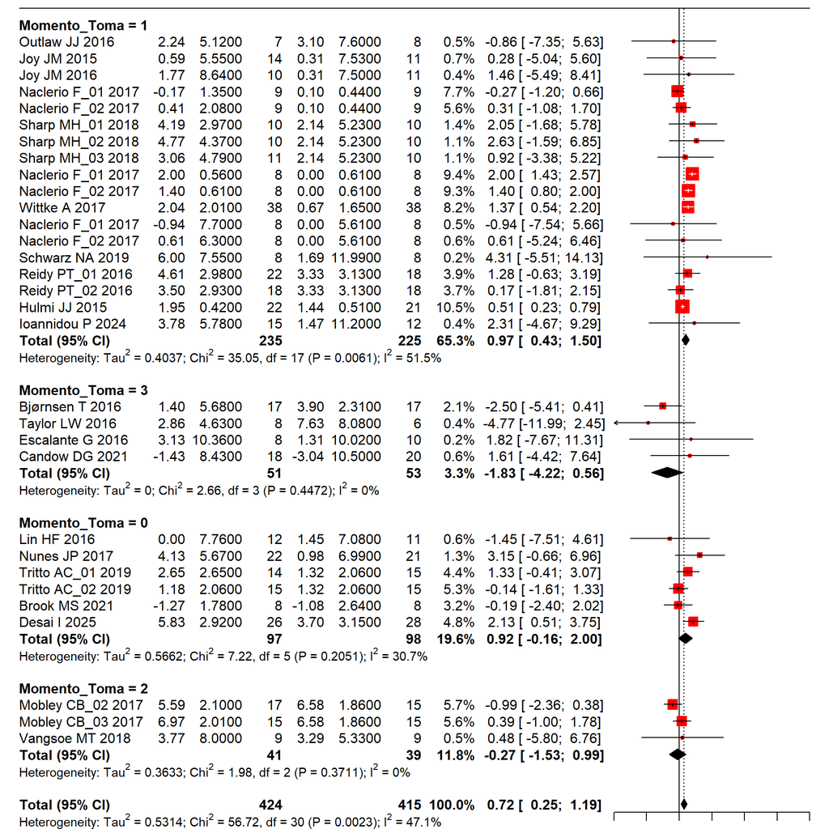

```r
g_timing <- metacont(
  n.e = N_Sup,
  mean.e = LMB_Suplemento,
  sd.e = SD_Suplemento,
  n.c = N_Con,
  mean.c = LMB_Control,
  sd.c = SD_Control,
  data = analisis_outliers,
  studlab = paste(Autor, Year),
  subgroup = Momento_Toma,
  common = FALSE,
  random = TRUE,
  method.tau = "REML"
)

forest(g_timing,
       comb.fixed = FALSE,
       print.pval.Q = TRUE,
       print.Q = TRUE,
       layout = "RevMan5",
       common = FALSE,
       random = TRUE,
       print.tau2 = TRUE,
       test.overall.random = TRUE,
       col.diamond = "black",
       col.square = "red",
       label.test.overall.random = TRUE,
       label.right = "Favorece suplemento",
       label.left = "Favorece control",
       col.square.lines = "red",
       spacing = 1,
       xlim = c(-10, 20))
```

## 6.5. Análisis por estado de entrenamiento

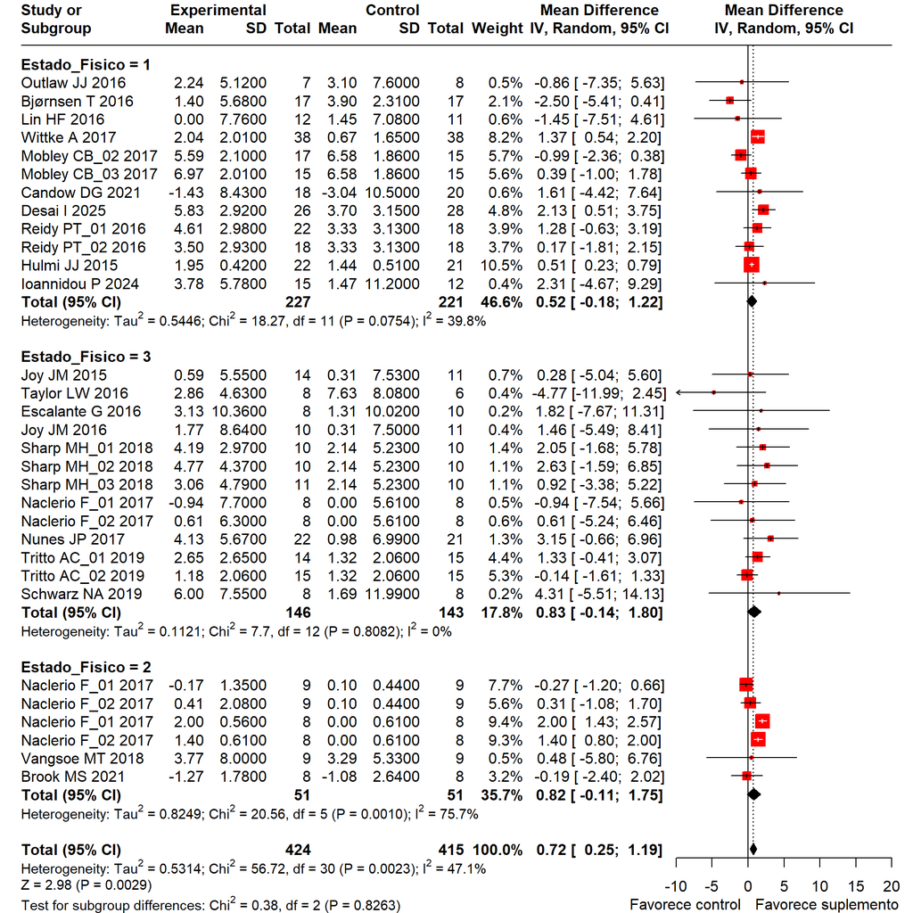

```r
g_trained <- metacont(
  n.e = N_Sup,
  mean.e = LMB_Suplemento,
  sd.e = SD_Suplemento,
  n.c = N_Con,
  mean.c = LMB_Control,
  sd.c = SD_Control,
  data = analisis_outliers,
  studlab = paste(Autor, Year),
  subgroup = Estado_Fisico,
  common = FALSE,
  random = TRUE,
  method.tau = "REML"
)

forest(g_trained,
       comb.fixed = FALSE,
       print.pval.Q = TRUE,
       print.Q = TRUE,
       layout = "RevMan5",
       common = FALSE,
       random = TRUE,
       print.tau2 = TRUE,
       test.overall.random = TRUE,
       col.diamond = "black",
       col.square = "red",
       label.test.overall.random = TRUE,
       label.right = "Favorece suplemento",
       label.left = "Favorece control",
       col.square.lines = "red",
       spacing = 1,
       xlim = c(-10, 20))
```

## 6.6. Análisis por edad

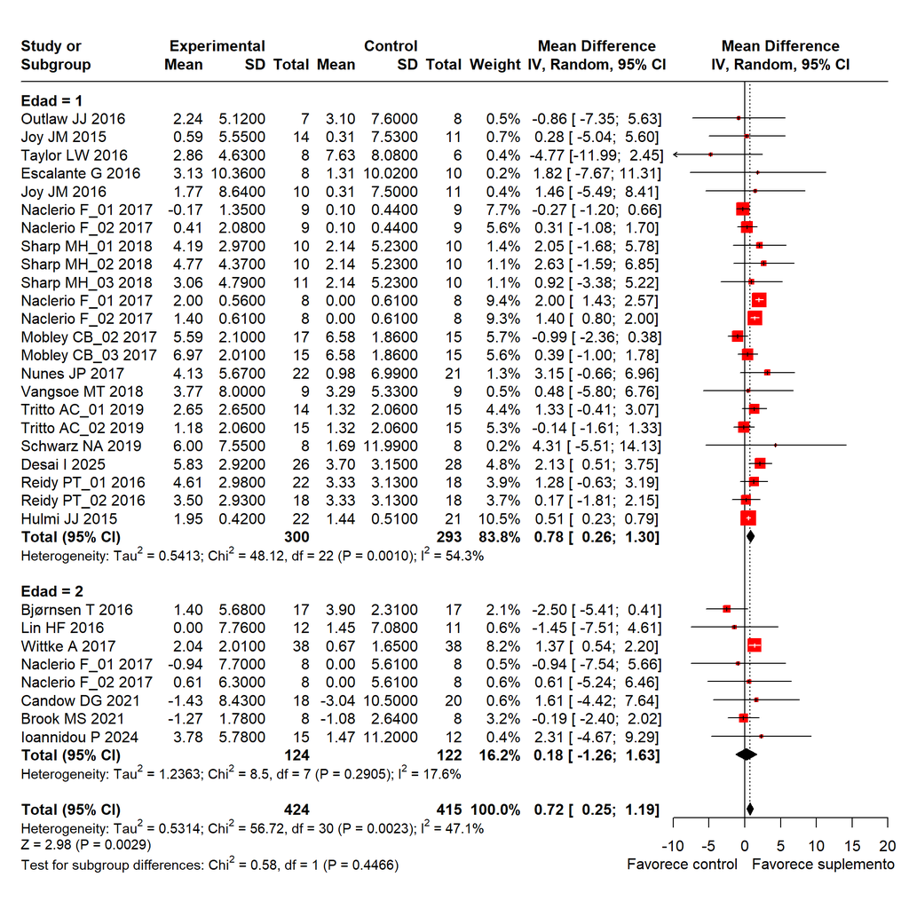

```r
g_edad <- metacont(
  n.e = N_Sup,
  mean.e = LMB_Suplemento,
  sd.e = SD_Suplemento,
  n.c = N_Con,
  mean.c = LMB_Control,
  sd.c = SD_Control,
  data = analisis_outliers,
  studlab = paste(Autor, Year),
  subgroup = Edad,
  common = FALSE,
  random = TRUE,
  method.tau = "REML"
)

forest(g_edad,
       comb.fixed = FALSE,
       print.pval.Q = TRUE,
       print.Q = TRUE,
       layout = "RevMan5",
       common = FALSE,
       random = TRUE,
       print.tau2 = TRUE,
       test.overall.random = TRUE,
       col.diamond = "black",
       col.square = "red",
       label.test.overall.random = TRUE,
       label.right = "Favorece suplemento",
       label.left = "Favorece control",
       col.square.lines = "red",
       spacing = 1,
       xlim = c(-10, 20))
```

# 7. Metarregresión: Análisis cuantitativo

La metarregresión busca analizar si existe correlación lineal entre una/varias variables con el efecto observado. Para ello, utilizamos las 2 variables continuas (edad y duración del experimento) en regresiones univariadas y luego una multivariada incluyendo todas las variables analizadas en el punto 6.

El estudio de las variables devuelve los siguientes factores:

- **QM**: Es el test de moderadores. Si su p_valor < 0.05 podemos afirmar que la variable explica parte del efecto observado.
- **R^2**: Indica el % de la heterogeneidad inicial explica dicha variable.
- **QE**: Indica la heterogeneidad residual que queda sin explicar.
- **Coeficiente (95% CI)**: Indican cómo se relacionan el efecto y la/s variable/s. Si es positivo, son directamente proporcionales, si es negativo, inversamente proporcionales.

```r
MR <- metacont(
  n.e = N_Sup,
  mean.e = LMB_Suplemento,
  sd.e = SD_Suplemento,
  n.c = N_Con,
  mean.c = LMB_Control,
  sd.c = SD_Control,
  data = analisis_metarregresion,
  studlab = paste(Autor, Year),
  common = FALSE,
  random = TRUE,
  method.tau = "REML"
)
```

## 7.1. Metarregresión univariada por Edad

```r
MR_edad <- metareg(MR, ~Edad)
summary(MR_edad)
```

```
##
## Mixed-Effects Model (k = 31; tau^2 estimator: REML)
##
##   logLik  deviance       AIC       BIC      AICc
## -55.3290  110.6580  116.6580  120.7599  117.6180
##
## tau^2 (estimated amount of residual heterogeneity):     0.5973 (SE = 0.3778)
## tau (square root of estimated tau^2 value):             0.7729
## I^2 (residual heterogeneity / unaccounted variability): 57.22%
## H^2 (unaccounted variability / sampling variability):   2.34
## R^2 (amount of heterogeneity accounted for):            0.00%
##
## Test for Residual Heterogeneity:
## QE(df = 29) = 56.0308, p-val = 0.0019
##
## Test of Moderators (coefficient 2):
## QM(df = 1) = 0.7178, p-val = 0.3969
##
## Model Results:
##
##          estimate      se     zval    pval    ci.lb   ci.ub
## intrcpt    1.2768  0.7128   1.7913  0.0732  -0.1202  2.6737  .
## Edad      -0.0183  0.0215  -0.8473  0.3969  -0.0605  0.0240
##
## ---
## Signif. codes:  0 '***' 0.001 '**' 0.01 '*' 0.05 '.' 0.1 ' ' 1
```

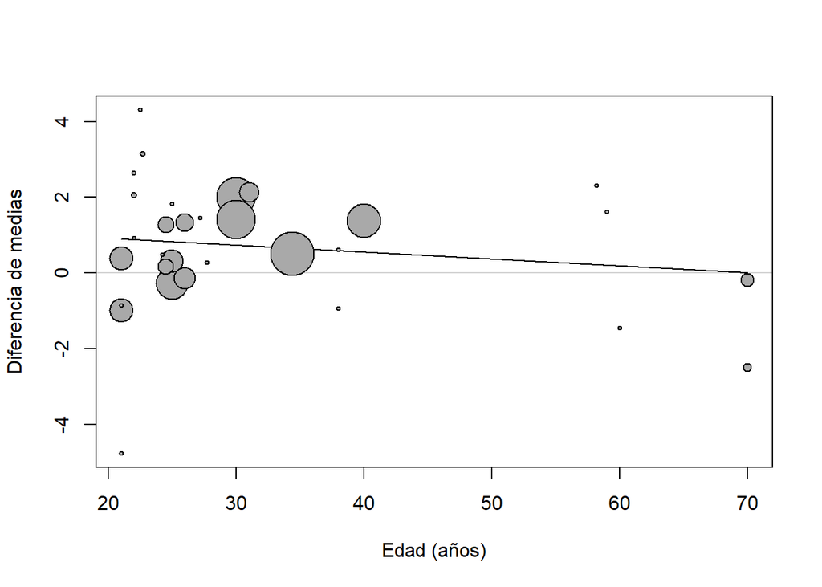

```r
bubble(MR_edad, xlab = "Edad (años)", ylab = "Diferencia de medias")
```

## 7.2. Metarregresión univariada por Duración del estudio

```r
MR_duracion <- metareg(MR, ~Duracion)
summary(MR_duracion)
```

```
##
## Mixed-Effects Model (k = 31; tau^2 estimator: REML)
##
##   logLik  deviance       AIC       BIC      AICc
## -55.3579  110.7158  116.7158  120.8177  117.6758
##
## tau^2 (estimated amount of residual heterogeneity):     0.5699 (SE = 0.3751)
## tau (square root of estimated tau^2 value):             0.7549
## I^2 (residual heterogeneity / unaccounted variability): 55.33%
## H^2 (unaccounted variability / sampling variability):   2.24
## R^2 (amount of heterogeneity accounted for):            0.00%
##
## Test for Residual Heterogeneity:
## QE(df = 29) = 56.2903, p-val = 0.0017
##
## Test of Moderators (coefficient 2):
## QM(df = 1) = 0.0941, p-val = 0.7590
##
## Model Results:
##
##           estimate      se    zval    pval    ci.lb   ci.ub
## intrcpt     0.5494  0.5882  0.9341  0.3503  -0.6034  1.7023
## Duracion    0.0145  0.0474  0.3068  0.7590  -0.0784  0.1075
##
## ---
## Signif. codes:  0 '***' 0.001 '**' 0.01 '*' 0.05 '.' 0.1 ' ' 1
```

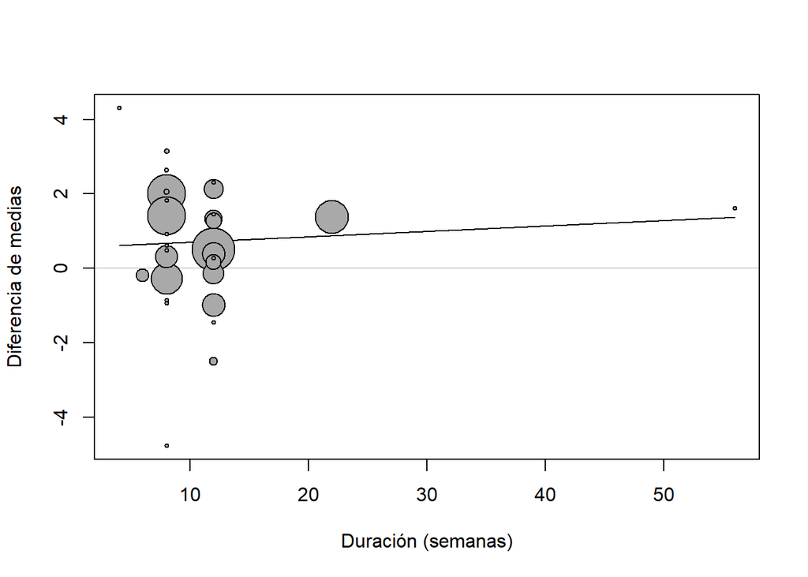

```r
bubble(MR_duracion, xlab = "Duración (semanas)", ylab = "Diferencia de medias")
```

## 7.3. Metarregresión multivariada con los 6 factores

```r
MR_completa <- metareg(MR, ~ Edad + Duracion + Suplemento + Momento_Toma + Estado_Fisico + Sexo)
summary(MR_completa)
```

```
##
## Mixed-Effects Model (k = 31; tau^2 estimator: REML)
##
##   logLik  deviance       AIC       BIC      AICc
## -45.1839   90.3679  106.3679  115.7923  115.9679
##
## tau^2 (estimated amount of residual heterogeneity):     0.6142 (SE = 0.4565)
## tau (square root of estimated tau^2 value):             0.7837
## I^2 (residual heterogeneity / unaccounted variability): 49.48%
## H^2 (unaccounted variability / sampling variability):   1.98
## R^2 (amount of heterogeneity accounted for):            0.00%
##
## Test for Residual Heterogeneity:
## QE(df = 24) = 41.3519, p-val = 0.0152
##
## Test of Moderators (coefficients 2:7):
## QM(df = 6) = 5.7786, p-val = 0.4484
##
## Model Results:
##
##                estimate      se     zval    pval    ci.lb   ci.ub
## intrcpt          2.2591  2.0377   1.1087  0.2676  -1.7346  6.2529
## Edad            -0.0238  0.0226  -1.0502  0.2936  -0.0682  0.0206
## Duracion         0.0380  0.0578   0.6576  0.5108  -0.0752  0.1512
## Suplemento      -0.0552  0.5357  -0.1031  0.9179  -1.1051  0.9947
## Momento_Toma    -0.8075  0.5494  -1.4699  0.1416  -1.8843  0.2692
## Estado_Fisico   -0.0146  0.3964  -0.0368  0.9707  -0.7916  0.7624
## Sexo            -0.1754  0.3187  -0.5504  0.5820  -0.8001  0.4492
##
## ---
## Signif. codes:  0 '***' 0.001 '**' 0.01 '*' 0.05 '.' 0.1 ' ' 1
```